# My YouTube Video Survey Report

## Plot One

[figure not shown]

This bar plot shows how many YouTube videos I watched per genre. I was interested in creating this plot because I wished to use it to find out which genres of video I watch the most. From the bar plot, I am able to see the five genres with the most videos watched, in descending order, and how many videos I have watched for each of these genres.

## Plot Two

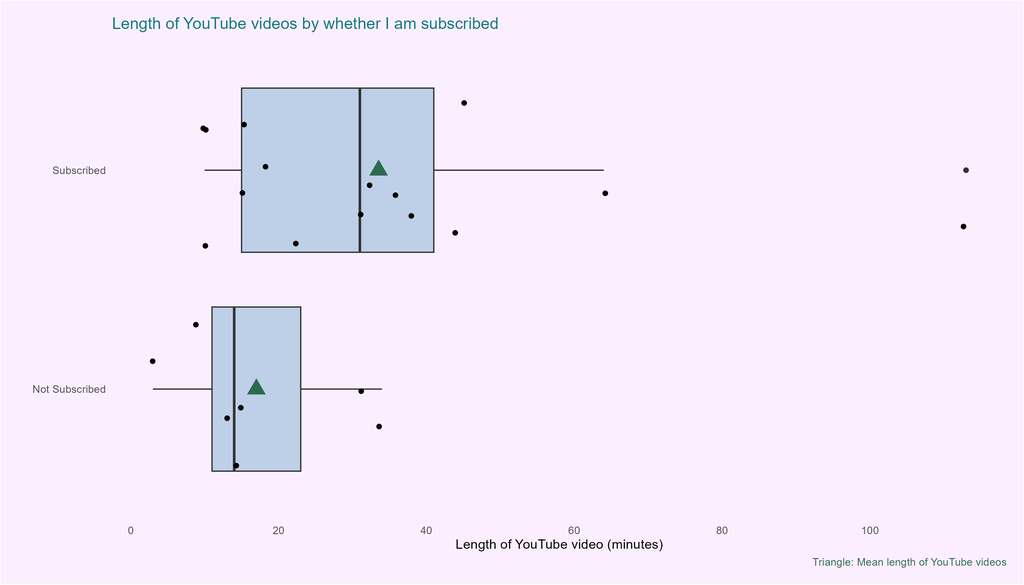

## Plot Three

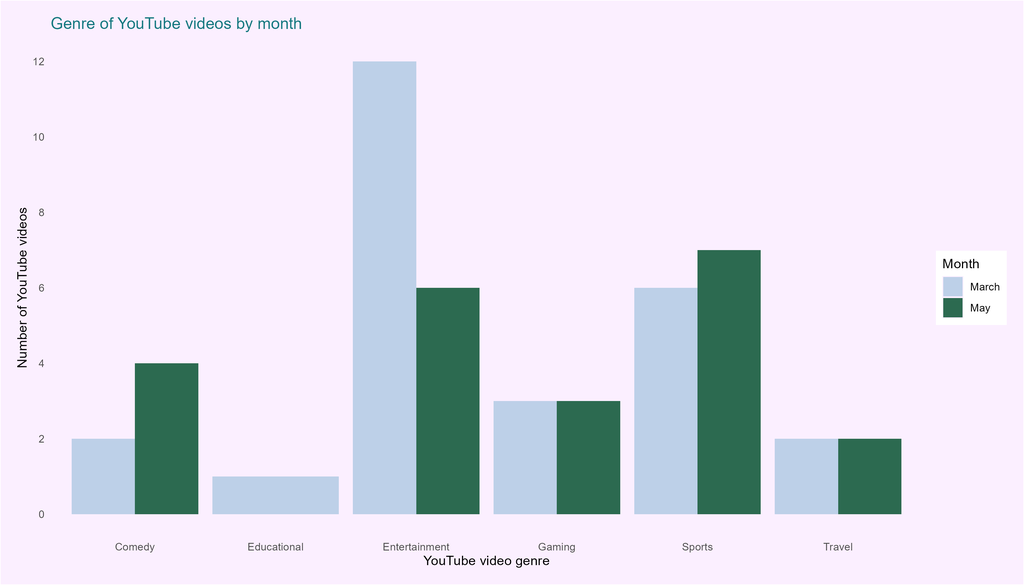

This bar plot shows how many YouTube videos of each genre that I watched per month. I decided to create this plot because the two months represent the videos watched for the two projects relating to this survey. This means that I can see if there are any correlations between whether I watched more videos of a certain genre during one project versus the other.